# 19_2 Data Engineering Assignment

Seongjin Kim

2019/12/10

—

# 1 분석 준비

## 1.1 ‘DVD 대여’ 데이터 설명 및 다운로드

[How I analyzed DVD rental data with SQL](https://www.freecodecamp.org/news/project-1-analyzing-dvd-rentals-with-sql-fd12dd674a64/)

위 링크에 접속해서 데이터를 다운로드한다. DVD 대여와 관련한 영화, 고객, 비용 지불과 관련한 데이터가 관계형 데이터베이스 형태로 업로드됐다.

아래는 관계형 데이터베이스에 대한 E-R 모델이다.

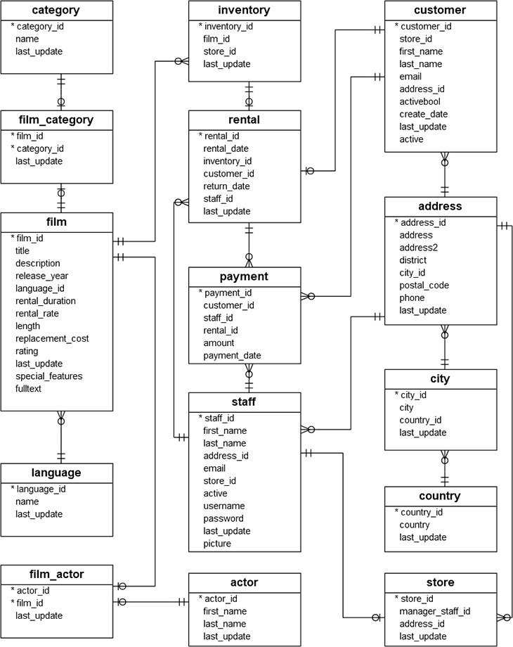

Database_Diagram

- 장르(category), 영화(film), 배우(actor), 구매(payment) 등과 관련한 데이터가 각기 구별된 테이블 저장돼 있다.
- 테이블 별로 각 데이터를 구분하는 `식별자`가 있는데 해당 변수는 좌측에 asteric`*`이 따로 표시돼 있다.
- 예를 들어 첫번째 테이블 `category`는 대여하는 16개 영화 장르(category)에 숫자를 부여한 건데, category_id를 기준으로 각 데이터가 구별된다.

## 1.2 데이터 베이스 다운로드 및 R과 postgreSQL 연결

관계형 데이터베이스를 다루기 위해 postgresSQL을 다운로드한다. 다운로드 링크는 다음과 같다.

[postgreSQL download](https://www.postgresql.org/download/windows/)

R에서 postgreSQL을 사용하려면 `RPostgreSQL`과 `DBI` 두 개 패키지가 필요하다.

데이터 분석을 위해 `tidyverse`도 탑재시킨다.

```r
pgdrv <- dbDriver("PostgreSQL")

con <- dbConnect(pgdrv, dbname="dvd",
                 port="5432",
                 user="postgres",
                 password=postgre_PW,
                 host="localhost")
```

데이터베이스를 postgreSQL 객체로 저장한다. dbDriver() 함수를 통해 postgreSQL에 저장한 데이터 베이스를 R로 불러온 뒤, dbConnect() 함수로 R 객체 `con`에 저장한다.

## 1.3 데이터베이스 다운로드

postgreSQL 관리자 통해 데이터 베이스를 테이블별로 확인할 수 있다. 편집기를 써서 데이터를 조정하고 수치 자료를 연산하기 위해 데이터를 R에 불러온다.

```r
# name of all tables to import from database
table_names <- c("category", "film_category", "film", "language", "film_actor", "inventory", "rental", "payment", "staff", "actor", "customer", "address", "city", "country", "store")

# list object to save data
data <- list()

# for loop
for(i in 1:length(table_names)){
  data[[i]] <- data.frame(dbGetQuery(con, paste("SELECT * FROM ", table_names[i], sep="")))
}

# change name of each table
names(data) <- table_names
```

`dbGetQuery()` 문을 반복해서 테이블 하나씩 불러올 수도 있겠지만, `for()` loop문을 이용해서 모든 테이블을 한번에 불러올 수도 있다.

데이터베이스의 테이블을 한 개씩 불러와서 R list 객체인 `data`에 저장한다.

## 1.4 테이블 자료

데이터를 분석할 때 계속 참고하기 위해 테이블 설명 자료를 미리 만들어둔다.

테이블의 이름과 데이터 갯수, 변수 갯수, 그리고 테이블 설명을 따로 저장해둔다.

```r
# empty object
number_of_rows <- c()
number_of_columns <- c()

# for loop to calculate number of rows and columns
for(i in 1:length(data)){
  number_of_rows[i] <- nrow(data[[i]])
  number_of_columns[i] <- ncol(data[[i]])
  cat(paste(i, ". ", table_names[i], " : ",  nrow(data[[i]]), " rows,", ncol(data[[i]]), " columns", sep=""), sep="\n")
}
```

```
## 1. category : 16 rows,3 columns
## 2. film_category : 1000 rows,3 columns
## 3. film : 1000 rows,13 columns
## 4. language : 6 rows,3 columns
## 5. film_actor : 5462 rows,3 columns
## 6. inventory : 4581 rows,4 columns
## 7. rental : 16044 rows,7 columns
## 8. payment : 14596 rows,6 columns
## 9. staff : 2 rows,11 columns
## 10. actor : 200 rows,4 columns
## 11. customer : 599 rows,10 columns
## 12. address : 603 rows,8 columns
## 13. city : 600 rows,4 columns
## 14. country : 109 rows,3 columns
## 15. store : 2 rows,4 columns
```

[Descriptions of tables](http://www.postgresqltutorial.com/postgresql-sample-database/)

위 링크에서 각 테이블과 관련한 설명을 찾을 수 있다. 설명을 텍스트 파일로 불러와 R에 저장한다.

```r
# description for each table
table_description <- read.table("data_description.txt", sep="\t", stringsAsFactors=FALSE)
table_description <- table_description[[1]]

table_description[1]
```

```
## [1] "actor ? stores actors data including first name and last name."
```

위 보이는 것과 같이, 각 데이터는 테이블 이름(actor)과 설명(‘stores actors data …’) 사이 물음표(?)로 구별돼 있다. 패키지 `rstring`(tidyverse에 포함)의 함수를 활용해 테이블 이름과 설명을 분ㄹ한다.

```r
# split texts between question mark
location_question_mark <- table_description %>% str_locate("\\?")

location_question_mark <- location_question_mark[,1]

location_question_mark[5] <- 15
length_description <- nchar(table_description)

Name <- table_description %>% str_sub(1, location_question_mark-2)

Description <- table_description %>% str_sub(location_question_mark+1, length_description)

table_names[!table_names %in% Name] # all other tables have description except for language리
```

```
## [1] "language"
```

위 코드를 실행하면 물음표를 앞 뒤로 테이블의 이름과 설명을 구분할 수 있다. 아래 코드를 통해 코드를 모든 테이블 자료에 적용한다.

```r
Name[length(Name)+1] <- "language"
Description[length(Description)+1] <- "Language support for each film"
index <- match(table_names, Name)# index to match between table_names and Name

Name_and_description <- cbind(Name, Description, index)

# reference about tables from sql database
table_data <- data.frame(Name = table_names, Rows = number_of_rows, Columns = number_of_columns)

indexed_description <- Description[index]

table_data <- cbind(table_data, indexed_description)

names(table_data) <- c("Names", "Rows", "Columns", "Descriptions")
```

관계형 데이터베이스에 포함됐던 테이블에 대한 자료는 다음과 같다.

```r
table_data %>% DT::datatable()
```

|  | Names | Rows | Columns | Descriptions |
| --- | --- | --- | --- | --- |
| 1 | category | 16 | 3 | stores film’s categories data. |
| 2 | film_category | 1000 | 3 | stores the relationships between films and categories. |
| 3 | film | 1000 | 13 | stores films data such as title, release year, length, rating, etc. |
| 4 | language | 6 | 3 | Language support for each film |
| 5 | film_actor | 5462 | 3 | stores the relationships between films and actors. |
| 6 | inventory | 4581 | 4 | stores inventory data. |
| 7 | rental | 16044 | 7 | stores rental data. |
| 8 | payment | 14596 | 6 | stores customer’s payments. |
| 9 | staff | 2 | 11 | stores staff data. |
| 10 | actor | 200 | 4 | stores actors data including first name and last name. |

[output cut: 5 more lines]

# 2 장르별 대여빈도

`Q. What are the top and least rented (in-demand) genres and what are their total sales?`

`수요가 가장 많고, 가장 적은 장르는 무엇이며, 장르별 매출은 얼마인가?`

장르별 DVD 대여 빈도를 확인하고, 인기가 가장 높거나 낮았던 장르를 파악한다. 또 장르별 DVD 대여 매출을 계산한다.

`category`에서 *name과 category_id*, `film_category`에서 *category_id와 film_id*, `inventory`에서 *film_id와 inventory_id*, `rental`에서 *inventory_id와 rental_id* `payment`에서 *rental_id와 amoun*를 연결한다.

문제 해결을 위해 `dplyr::group_by()`로 장르(name)별 amount를 합산한다.

## 2.1 데이터 병합

필요한 것은 `category` `film_category` `inventory` `rental` `payment` 모두 다섯개 테이블이다.

```r
needed_tables <- c("category", "film_category", "inventory", "rental", "payment")
index <- match(needed_tables, table_data[,"Names"])

category <- data[[index[1]]]
film_category <- data[[index[2]]]
inventory <- data[[index[3]]]
rental <- data[[index[4]]]
payment <- data[[index[5]]]

# get rid of "last_update"
category <- category[,-ncol(category)]
film_category <- film_category[,-ncol(film_category)]
inventory <- inventory[,-ncol(inventory)]
rental <- rental[,-ncol(rental)]
payment <- payment[,-ncol(payment)]
```

### 2.1.1 데이터 병합, 장르 식별자와 이름

영화 장르의 id를 정의한 테이블 `category`와 영화별로 category_id를 부여한 테이블 `film_category`를 병합한다.

```r
category_and_film_category <- right_join(category, film_category, by = "category_id")
```

`film_category`는 영화(film_id)과 장르(category_id)를 연결한 테이블이다. 여기 film_id를 식별자로 해서, 장르명(name)을 붙여야 한다. 따라서 category와 film_category를 순서대로 적고 right_join을 적용한다.

또 위에 적은 순서에 맞게 데이터 병합을 계속한다. 어쨌든 최종 식별자는 payment(거래 건수)가 돼야 하는데, 따라서, 영화 -> 렌탈 -> payment까지 가면서 right_join으로 연결하도록 한다.

```r
film_category_and_inventory <- right_join(category_and_film_category, inventory, by = "film_id")
inventory_and_rental <- right_join(film_category_and_inventory, rental, by = "inventory_id")

# customer_id would be duplicated
inventory_and_rental <- inventory_and_rental[, -which(colnames(inventory_and_rental)=="customer_id")]
rental_and_payment <- right_join(inventory_and_rental, payment, by = "rental_id")

rental_and_payment %>% DT::datatable()
```

|  | category_id | name | film_id | inventory_id | store_id | rental_id | rental_date | return_date | staff_id.x | payment_id | customer_id | staff_id.y | amount |
| --- | --- | --- | --- | --- | --- | --- | --- | --- | --- | --- | --- | --- | --- |
| 1 | 11 | Horror | 749 | 3419 | 1 | 1520 | 2005-06-15T14:57:20Z | 2005-06-24T14:46:20Z | 1 | 17503 | 341 | 2 | 7.99 |
| 2 | 6 | Documentary | 552 | 2512 | 2 | 1778 | 2005-06-16T09:54:48Z | 2005-06-22T07:08:48Z | 2 | 17504 | 341 | 1 | 1.99 |
| 3 | 13 | New | 551 | 2507 | 1 | 1849 | 2005-06-16T15:13:19Z | 2005-06-23T09:37:19Z | 2 | 17505 | 341 | 1 | 7.99 |
| 4 | 4 | Classics | 445 | 2047 | 1 | 2829 | 2005-06-19T12:11:30Z | 2005-06-24T09:10:30Z | 1 | 17506 | 341 | 2 | 2.99 |
| 5 | 10 | Games | 563 | 2569 | 1 | 3130 | 2005-06-20T10:03:22Z | 2005-06-29T09:05:22Z | 2 | 17507 | 341 | 2 | 7.99 |
| 6 | 14 | Sci-Fi | 26 | 131 | 1 | 3382 | 2005-06-21T05:05:23Z | 2005-06-29T10:13:23Z | 2 | 17508 | 341 | 1 | 5.99 |
| 7 | 9 | Foreign | 961 | 4398 | 2 | 2190 | 2005-06-17T16:29:51Z | 2005-06-25T19:31:51Z | 2 | 17509 | 342 | 2 | 5.99 |
| 8 | 11 | Horror | 527 | 2419 | 2 | 2914 | 2005-06-19T18:43:18Z | 2005-06-24T18:44:18Z | 2 | 17510 | 342 | 1 | 5.99 |
| 9 | 14 | Sci-Fi | 449 | 2071 | 2 | 3081 | 2005-06-20T06:29:13Z | 2005-06-24T12:00:13Z | 2 | 17511 | 342 | 1 | 2.99 |
| 10 | 8 | Family | 639 | 2909 | 2 | 1547 | 2005-06-15T16:42:24Z | 2005-06-18T16:13:24Z | 1 | 17512 | 343 | 2 | 4.99 |

[output cut: 14586 more lines]

```r
#glimpse(rental_and_payment)
total_sales_by_genre <- rental_and_payment %>%
  group_by(name) %>%
  summarise(total_sales = sum(amount))

total_sales_by_genre %>% DT::datatable()
```

|  | name | total_sales |
| --- | --- | --- |
| 1 | Action | 3951.84 |
| 2 | Animation | 4245.31 |
| 3 | Children | 3309.39 |
| 4 | Classics | 3353.38 |
| 5 | Comedy | 4002.48 |
| 6 | Documentary | 3749.65 |
| 7 | Drama | 4118.46 |
| 8 | Family | 3830.15 |
| 9 | Foreign | 3934.47 |
| 10 | Games | 3922.18 |

[output cut: 6 more lines]

```r
sales <- pull(total_sales_by_genre[,"total_sales"])

cat(paste("Top Selling :", total_sales_by_genre[which.max(sales),"name"]), "\n",
    paste("Least Selling :", total_sales_by_genre[which.min(sales),"name"]), "\n")
```

```
## Top Selling : Sports
##  Least Selling : Music
```

- 장르중 Sports의 매출이 가장 높고, Music의 매출이 가장 낮다.

# 3 장르별 대여 고객 수

`Can we know how many distinct users have rented each genre?`

```r
rental_and_inventory <- left_join(rental, inventory, by = "inventory_id")
rental_and_category <- left_join(rental_and_inventory, film_category, by = "film_id")
rental_and_genre <- left_join(rental_and_category, category, by = "category_id")

glimpse(rental_and_genre)
```

```
## Observations: 16,044
## Variables: 10
## $ rental_id    <int> 2, 3, 4, 5, 6, 7, 8, 9, 10, 11, 12, 13, 14, 15, 1...
## $ rental_date  <dttm> 2005-05-24 22:54:33, 2005-05-24 23:03:39, 2005-0...
## $ inventory_id <int> 1525, 1711, 2452, 2079, 2792, 3995, 2346, 2580, 1...
## $ customer_id  <int> 459, 408, 333, 222, 549, 269, 239, 126, 399, 142,...
## $ return_date  <dttm> 2005-05-28 19:40:33, 2005-06-01 22:12:39, 2005-0...
## $ staff_id     <int> 1, 1, 2, 1, 1, 2, 2, 1, 2, 2, 2, 1, 1, 1, 2, 1, 2...
## $ film_id      <int> 333, 373, 535, 450, 613, 870, 510, 565, 396, 971,...
## $ store_id     <int> 2, 2, 1, 2, 1, 2, 1, 1, 2, 1, 1, 1, 2, 1, 1, 2, 1...
## $ category_id  <int> 12, 3, 11, 3, 5, 11, 2, 9, 7, 9, 16, 8, 11, 6, 12...
## $ name         <chr> "Music", "Children", "Horror", "Children", "Comed...
```

```r
genres <- unique(rental_and_genre$name)
number_of_users <- c()
for(i in 1:length(genres)){
  index <- rental_and_genre$name==genres[i]
  interim_data <- rental_and_genre[index, ]
  number_of_users[i] <- length(unique(interim_data$customer_id))
}

number_users_by_genre <- cbind(genres, number_of_users)

number_users_by_genre %>% DT::datatable()
```

| genres | number_of_users |
| --- | --- |
| Music | 447 |
| Children | 482 |
| Horror | 451 |
| Comedy | 495 |
| Animation | 500 |
| Foreign | 493 |
| Drama | 501 |
| Travel | 442 |
| Family | 501 |
| Documentary | 483 |

[output cut: 6 more lines]

# 4 장르별 평균 대여 비율

`What is the average rental rate for each genre? (from the highest to the lowest)`

```r
film <- data[[3]]

film_and_film_category <- right_join(category_and_film_category, film, by = "film_id")

rental_rate_by_genre <- film_and_film_category %>%
  group_by(name) %>%
  summarise(rental_rate_by_genre = mean(rental_rate))
```

[output not shown]

# 5 기간 내 반납 여부

`How many rented films were returned late, early, and on time?`

`대여한 DVD 중 제 때 반납한 것, 연체, 정시 반납한 게 각각 몇 건인가?`

테이블 `film`에 *rental_duration* 변수가 있다.각 dvd 마다 대여 기간이 다른건데, return_date와 rental_date 간 차이를 구해 모두 며칠 대여했는지를 구하고, 이를 rental_duration과 비교해 연체 여부를 확인한다.

```r
library(lubridate)
film_and_inventory <- right_join(film, inventory, by = "film_id")
film_and_inventory_and_rental <- right_join(film_and_inventory, rental, by = "inventory_id")
```

테이블 `rental`의 *rental_id*가 테이블 `film`의 *rental_duration*까지 이어져야 한다. 먼저 film과 inventory를 이을 건데, 결국 대여의 기초가 되는 것은 인벤토리기 때문에 inventory_id를 기준으로 병합해야 한다. 이에 film, inventory를 차례로 쓰고 right_join() 해준다.

병합한 데이터와 rental을 병합해야 한다. 식별자 rental_id가 있는 테이블 `rental`을 기준으로 join해야 한다. 이에 앞서 병합한 데이터와 rental을 차례로 써준 뒤, right_join() 해준다.

```r
question4_data <- film_and_inventory_and_rental %>%
  mutate(rental_period = day(as.period(return_date - rental_date))) %>% # add rental_period
  mutate(rental_status = ifelse(rental_period > rental_duration, "late", ifelse(rental_period == rental_duration, "on time", "early"))) # conditional statement to add rental_status

colSums(is.na(question4_data)) # 183 NAs in return_date
```

```
##          film_id            title      description     release_year
##                0                0                0                0
##      language_id  rental_duration      rental_rate           length
##                0                0                0                0
## replacement_cost           rating      last_update special_features
##                0                0                0                0
##         fulltext     inventory_id         store_id        rental_id
##                0                0                0                0
##      rental_date      customer_id      return_date         staff_id
##                0                0              183                0
##    rental_period    rental_status
##              183              183
```

- mutate() 함수를 통해 새 변수를 만들어야 하기 때문에 question4_data라는 새로운 데이터프레임을 만들었다.
- 위에 colSums(is.na(question4_data)) 통해 각 column 별로 NA 값이 몇 개 있나 확인할 수 있다. 보면, return_date에 NA 183개가 있다. 이는 빌려 놓고 반납하지 않은 건수가 183 건 있다는 뜻이다.
- 반납하지 않은 것은 여기서 연체(late)와 동일하게 처리한다. 이에 NA 값은 “late”로 대체하도록 한다.

```r
rental_status <- question4_data[,"rental_status"]

# replace NAs with "late"
NA_index <- which(is.na(rental_status))
rental_status[NA_index] <- "late"

cat(paste("Late : ", sum(rental_status=="late"), " (", round(sum(rental_status=="late")/length(rental_status)*100, 2), "%)", sep=""), "\n",
    paste("On Time :", sum(rental_status=="on time"), " (", round(sum(rental_status=="on time")/length(rental_status)*100, 2), "%)", sep=""), "\n",
    paste("Early :", sum(rental_status=="early"), " (", round(sum(rental_status=="early")/length(rental_status)*100, 2), "%)", sep=""), "\n")
```

```
## Late : 6586 (41.05%)
##  On Time :1720 (10.72%)
##  Early :7738 (48.23%)
```

# 6 국가별 분석

`In which countries does Rent A Film have a presence and what is the customer base in each country? What are the total sales in each country? (from most to least)`

`Rent A Film이 어느 국가에 서비스 중이고, 서비스를 가장 활발히 사용하는 고객의 특징은 어떻게 되나? 국가별 총 매출은 어떻게 되나?`

```r
# country
country <- data[[14]]
country <- country[, -ncol(country)] # delete last_update
# city
city <- data[[13]]
city <- city[, -ncol(city)] # delete last_update
# customer
customer <- data[[11]]
customer <- customer[, -ncol(customer)]
# address
address <- data[[12]]
address <- address[,-ncol(address)]
```

```r
length(unique(country$country))
```

```
## [1] 109
```

- `Rent A Film`은 모두 109개 나라에 서비스를 제공하고 있다. 109개 나라 모두 매출이 발생했는지 확인하기 위해 데이터 정제 작업이 더 필요하다. 구체적인 국가명은 아래 자료를 더 병합한 테이블 통해 보일 계획이다.
- customer base란 기업의 상품과 서비스를 활발히 구매하는 고객 그룹(특징과 구분)을 의미한다. 고객과 관련한 정보는 많지 않기 때문에 고객이 가장 많이 분포한 지역과 매장을 파악한다.

```r
customer_and_address <- left_join(customer, address, by = "address_id")
customer_and_city <- left_join(customer_and_address, city, by = "city_id")
customer_and_country <- left_join(customer_and_city, country, by = "country_id")
```

- 테이블 `customer`에 있는 고객 관련 자료들과 `country`를 연결한다.

```r
by_city <- customer_and_country %>%
  group_by(city) %>%
  summarise(number_of_customers = length(unique(customer_id)), number_of_stores = length(unique(store_id)))
```

`payment`의 customer_id 통해 `customer`과 연결 `customer`의 address_id 통해 `address`와 연결 `address`의 city_id 통해 `city`와 연결 `city`의 country_id 통해 `country`와 연결

```r
payment_and_customer <- left_join(payment, customer, by = "customer_id")
payment_and_address <- left_join(payment_and_customer, address, by = "address_id")
payment_and_city <- left_join(payment_and_address, city, by = "city_id")
payment_and_country <- left_join(payment_and_city, country, by = "country_id")
```

```r
number_of_stores_and_customers <- payment_and_city %>%
  group_by(city_id) %>%
  summarise(number_of_stores = length(unique(store_id)), number_of_customers = length(unique(customer_id)), sales_by_city = sum(amount))

city_and_numbers <- left_join(city, number_of_stores_and_customers, by = "city_id")
country_and_numbers <- left_join(city_and_numbers, country, by = "country_id")
```

- 도시별 매장과 고객 수를 파악하고자 한다. 이를 위해 group_by() 함수 통해 city_id 별로 store_id와 customer_id의 개수를 파악한다.
- 그런데 파악한 결과, 도시별 매장과 고객의 수가 거의 1개인 것으로 계산된다. 글로벌한 회사가, 도시별로 고객이 한명뿐일리가 없는데, 다운로드한 데이터베이스가 샘플이기 때문인 것으로 보인다.

```r
total_sales_by_country <- payment_and_country %>%
  group_by(country) %>%
  summarise(total_sales_by_country = sum(amount))

# search for NA or 0
which(is.na(total_sales_by_country$total_sales_by_country))
```

```
## integer(0)
```

```r
which(total_sales_by_country$total_sales_by_country==0)
```

```
## integer(0)
```

```r
# returns none
```

```r
customer_base <- country_and_numbers %>%
  group_by(country) %>%
  summarise(outselling_city = max(sales_by_city))

customer_base %>% DT::datatable()
```

|  | country | outselling_city |
| --- | --- | --- |
| 1 | Afghanistan | 67.82 |
| 2 | Algeria | 151.68 |
| 3 | American Samoa | 47.85 |
| 4 | Angola | 93.8 |
| 5 | Anguilla | 99.68 |
| 6 | Argentina | 129.71 |
| 7 | Armenia | 118.75 |
| 8 | Australia |  |
| 9 | Austria | 113.74 |
| 10 | Azerbaijan | 108.75 |

[output cut: 99 more lines]

# 7 최우수 고객

`Who are the top 5 customers per total sales and can we get their details just in case Rent A Film wants to reward them?`

`최우수 고객 다섯명에 대한 자료를 정리해라`

```r
top_5_customers <- payment_and_customer %>%
  group_by(customer_id) %>%
  summarise(total_purchase_by_customer = sum(amount))

index <- which(order(top_5_customers$total_purchase_by_customer, decreasing = TRUE) %in% 1:5)
top_5_customers_id <- top_5_customers$customer_id[index] # ids for top 5 customers
top_5_customers_purchase <- top_5_customers$total_purchase_by_customer[index]
```

- `customer_id` 별로 묶어서 매출을 모두 합한다. 이때 order() 함수를 써서 매출의 순위를 파악할 수 있다. 순위가 1~5에 해당하는 데이터의 자료 순서를 찾아 객체 *index*에 저장한다.

```r
index <- which(customer$customer_id %in% top_5_customers_id)
top_5_customer_data <- customer[index, ]

top_5_customer_data %>% DT::datatable()
```

|  | customer_id | store_id | first_name | last_name | email | address_id | activebool | create_date | last_update |
| --- | --- | --- | --- | --- | --- | --- | --- | --- | --- |
| 63 | 62 | 1 | Joan | Cooper | joan.cooper@sakilacustomer.org | 66 | True | 2006-02-14 | 2013-05-26T05:49:45Z |
| 75 | 74 | 1 | Denise | Kelly | denise.kelly@sakilacustomer.org | 78 | True | 2006-02-14 | 2013-05-26T05:49:45Z |
| 110 | 109 | 2 | Edna | West | edna.west@sakilacustomer.org | 113 | True | 2006-02-14 | 2013-05-26T05:49:45Z |
| 170 | 169 | 2 | Erica | Matthews | erica.matthews@sakilacustomer.org | 173 | True | 2006-02-14 | 2013-05-26T05:49:45Z |
| 477 | 476 | 1 | Derrick | Bourque | derrick.bourque@sakilacustomer.org | 481 | True | 2006-02-14 | 2013-05-26T05:49:45Z |

```r
customer_and_payment <- left_join(customer, payment, by = "customer_id")
customer_and_rental <- left_join(customer_and_payment, rental, by = "rental_id")
customer_and_inventory <- left_join(customer_and_rental, inventory, by = "inventory_id")
customer_and_film <- left_join(customer_and_inventory, film, by = "film_id")
customer_and_film_category <- left_join(customer_and_film, film_category, by = "film_id")

# take rental status and rental id from question4_data
interim_data <- question4_data[, which(colnames(question4_data) %in% c("rental_id", "rental_status"))]

customer_and_film_rental <- left_join(customer_and_film_category, interim_data, by = "rental_id")
```

```r
index <- customer_and_film_rental$customer_id.x %in% top_5_customers_id
top_5_data <- customer_and_film_rental[index, ]
```

dplyr::group_by()를 사용해서 최우수 고객의 총 구매금액과 가장 활발하게 대여했던 영화 장르, 가장 자주 찾았던 매장과 기간 내 반납 비율을 계산한다.

```r
top_5_details <- top_5_data %>%
  group_by(customer_id.x) %>%
  summarise(Purchase = sum(amount),
            Preference = max(table(category_id)),
            Store = max(table(store_id.x)),
            Return_Rate = round(sum(rental_status!="late")/sum(rental_status=="late"|rental_status=="early"|rental_status=="on time")*100, 2)
            )

# slight moderation (1) change column name (2) find name of genre
colnames(top_5_details)[1] <- "customer_id"


index <- which(customer$customer_id %in% top_5_customers_id)

top_5_info <- customer[index, which(names(customer) %in% c("customer_id", "first_name", "last_name", "email", "address_id", "create_date"))]

top_5_info <- top_5_info %>%
  mutate(Names = paste(first_name, last_name), Customer_duration = as.Date(now())-create_date)

top_5_detailed_information <- left_join(top_5_info, top_5_details, by = "customer_id")

# genre names => 4(Classics), 5(Comedy)

genre_factor <- factor(c(5, 5, 4, 5, 4), levels = c(4, 5), labels = c("Classics", "Comedy"))
top_5_detailed_information[,"Preference"] <- genre_factor

top_5_detailed_information %>% DT::datatable()
```

|  | customer_id | first_name | last_name | email | address_id | create_date | Names | Customer_duration | Purchase | Preference | Store | Return_Rate |
| --- | --- | --- | --- | --- | --- | --- | --- | --- | --- | --- | --- | --- |
| 1 | 62 | Joan | Cooper | joan.cooper@sakilacustomer.org | 66 | 2006-02-14 | Joan Cooper | 5049 | 78.79 | Comedy | 21 | 57.14 |
| 2 | 74 | Denise | Kelly | denise.kelly@sakilacustomer.org | 78 | 2006-02-14 | Denise Kelly | 5049 | 96.74 | Comedy | 26 | 50 |
| 3 | 109 | Edna | West | edna.west@sakilacustomer.org | 113 | 2006-02-14 | Edna West | 5049 | 79.81 | Classics | 19 | 47.37 |
| 4 | 169 | Erica | Matthews | erica.matthews@sakilacustomer.org | 173 | 2006-02-14 | Erica Matthews | 5049 | 86.8 | Comedy | 20 | 75 |
| 5 | 476 | Derrick | Bourque | derrick.bourque@sakilacustomer.org | 481 | 2006-02-14 | Derrick Bourque | 5049 | 87.8 | Classics | 20 |  |